# Introduction

**This is a Portfolio Project from 100 Days of Code: The Complete Python Pro Bootcamp.**

Since Jan. 1, 2015, [The Washington Post](https://www.washingtonpost.com/) has been compiling a database of every fatal shooting in the US by a police officer in the line of duty.

While there are many challenges regarding data collection and reporting, The Washington Post has been tracking more than a dozen details about each killing. This includes the race, age and gender of the deceased, whether the person was armed, and whether the victim was experiencing a mental-health crisis. The Washington Post has gathered this supplemental information from law enforcement websites, local new reports, social media, and by monitoring independent databases such as "Killed by police" and "Fatal Encounters". The Post has also conducted additional reporting in many cases.

There are 4 additional datasets: US census data on poverty rate, high school graduation rate, median household income, and racial demographics. [Source of census data](https://factfinder.census.gov/faces/nav/jsf/pages/community_facts.xhtml).

### Upgrade Plotly

Run the cell below if you are working with Google Colab

```python
%pip install --upgrade plotly
```

## Import Statements

```python
import numpy as np
import pandas as pd
import plotly.express as px
import matplotlib.pyplot as plt
import seaborn as sns
from sklearn.linear_model import LinearRegression
```

## Notebook Presentation

```python
pd.options.display.float_format = '{:,.2f}'.format
```

## Load the Data

```python
df_hh_income = pd.read_csv('Median_Household_Income_2015.csv', encoding="windows-1252")
df_pct_poverty = pd.read_csv('Pct_People_Below_Poverty_Level.csv', encoding="windows-1252")
df_pct_completed_hs = pd.read_csv('Pct_Over_25_Completed_High_School.csv', encoding="windows-1252")
df_share_race_city = pd.read_csv('Share_of_Race_By_City.csv', encoding="windows-1252")
df_fatalities = pd.read_csv('Deaths_by_Police_US.csv', encoding="windows-1252")
```

# Preliminary Data Exploration

- What is the shape of the DataFrames?

```python
print(df_fatalities.shape, df_hh_income.shape, df_pct_completed_hs.shape, df_pct_poverty.shape, df_share_race_city.shape)
```

```
(2535, 14) (29322, 3) (29329, 3) (29329, 3) (29268, 7)
```

- Column names:

```python
print(df_fatalities.columns, df_hh_income.columns, df_pct_completed_hs.columns, df_pct_poverty.columns, df_share_race_city.columns)
```

```
Index(['id', 'name', 'date', 'manner_of_death', 'armed', 'age', 'gender',
       'race', 'city', 'state', 'signs_of_mental_illness', 'threat_level',
       'flee', 'body_camera'],
      dtype='object') Index(['Geographic Area', 'City', 'Median Income'], dtype='object') Index(['Geographic Area', 'City', 'percent_completed_hs'], dtype='object') Index(['Geographic Area', 'City', 'poverty_rate'], dtype='object') Index(['Geographic area', 'City', 'share_white', 'share_black',
       'share_native_american', 'share_asian', 'share_hispanic'],
      dtype='object')
```

- Checking for NaN values and duplicates:

```python
print(df_fatalities.isna().values.any(), df_hh_income.isna().values.any(), df_pct_completed_hs.isna().values.any(), df_pct_poverty.isna().values.any(), df_share_race_city.isna().values.any())
```

```
True True False False False
```

```python
print(df_fatalities.isna().values.sum(), df_hh_income.isna().values.sum())
```

```
346 51
```

```python
print(df_fatalities.duplicated().values.sum(), df_hh_income.duplicated().values.sum(), df_pct_completed_hs.duplicated().values.sum(), df_pct_poverty.duplicated().values.sum(), df_share_race_city.duplicated().values.sum())
```

```
0 0 0 0 0
```

## Data Cleaning

- Changing necessary columns from object type to numeric:

```python
df_pct_poverty['poverty_rate'] = pd.to_numeric(df_pct_poverty['poverty_rate'], errors='coerce')
```

```python
df_pct_completed_hs['percent_completed_hs'] = pd.to_numeric(df_pct_completed_hs['percent_completed_hs'], errors='coerce')
```

```python
df_share_race_city['share_white'] = pd.to_numeric(df_share_race_city['share_white'], errors='coerce')
df_share_race_city['share_black'] = pd.to_numeric(df_share_race_city['share_black'], errors='coerce')
df_share_race_city['share_native_american'] = pd.to_numeric(df_share_race_city['share_native_american'], errors='coerce')
df_share_race_city['share_asian'] = pd.to_numeric(df_share_race_city['share_asian'], errors='coerce')
df_share_race_city['share_hispanic'] = pd.to_numeric(df_share_race_city['share_hispanic'], errors='coerce')
```

- Changing the date column's type into datetype:

```python
df_fatalities['date'] = df_fatalities['date'].apply(pd.to_datetime)
```

# Chart the Poverty Rate in each US State

To start with we're going to create a bar chart displaying average poverty rates across all the US states.

```python
poverty_rate_by_state = df_pct_poverty.groupby('Geographic Area', as_index=False).agg({'poverty_rate': pd.Series.mean})
```

```python
poverty_rate_by_state = poverty_rate_by_state.sort_values('poverty_rate', ascending=False)
```

```python
bar = px.bar(y=poverty_rate_by_state['poverty_rate'],
               x=poverty_rate_by_state['Geographic Area'],
               title='Average Poverty Rate by US State',
               color=poverty_rate_by_state['poverty_rate'],
               color_continuous_scale='Brwnyl')

bar.update_layout(xaxis_title='US State', yaxis_title='Poverty Rate', coloraxis_showscale=False)

bar.show()
bar.write_html('1Average_poverty_rate_by_us_state.html')
```

[interactive chart not shown]

The state with the **highest poverty rate is Mississippi (MS) at almost 27%**, followed by Arizona (AZ) at 25.6%. The **lowest poverty rate is in the state of New Jersey (NJ)** with only 8.2%.

# Chart the High School Graduation Rate by US State

Now, we're going to chart the average High School Graduation Rate across all the US states and see if it coincides with the poverty rates.

```python
hs_graduation_by_state = df_pct_completed_hs.groupby('Geographic Area', as_index=False).agg({'percent_completed_hs': pd.Series.mean})
```

```python
hs_graduation_by_state = hs_graduation_by_state.sort_values('percent_completed_hs', ascending=False)
```

```python
bar = px.bar(y=hs_graduation_by_state['percent_completed_hs'],
               x=hs_graduation_by_state['Geographic Area'],
               title='Average High School Graduation Rate by US State',
               color=hs_graduation_by_state['percent_completed_hs'],
               color_continuous_scale='mint')

bar.update_layout(xaxis_title='US State', yaxis_title='High School Graduation Rate', coloraxis_showscale=False)

bar.show()
bar.write_html('2Average_high_school_graduation_rate.html')
```

[interactive chart not shown]

**Massachusetts (MA) has the highest average high school graduation rate at 92%.** The lowest graduation rate is in Texas (TX) at only 75.7%.

# Visualise the Relationship between Poverty Rates and High School Graduation Rates

To analyse the relationship between poverty rates and high school graduation rates we're going to create a line chart with two y-axes to show if the rations of poverty and high school graduation move together.

```python
poverty_rate_by_state = poverty_rate_by_state.sort_values('Geographic Area')
```

```python
hs_graduation_by_state = hs_graduation_by_state.sort_values('Geographic Area')
```

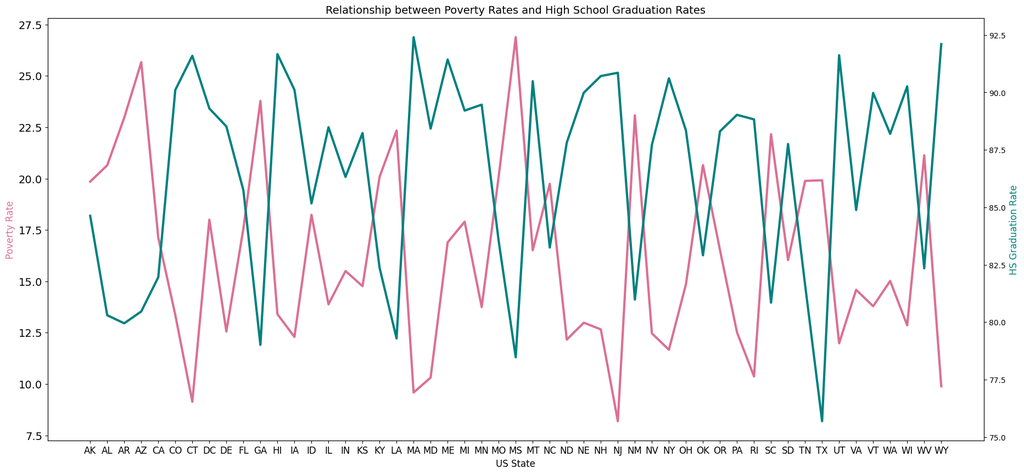

```python
plt.figure(figsize=(22,10))
plt.xticks(fontsize=12)
plt.yticks(fontsize=14)
ax1=plt.gca()
ax2=ax1.twinx()
ax1.plot(poverty_rate_by_state['Geographic Area'], poverty_rate_by_state['poverty_rate'], color='palevioletred', linewidth=3)
ax2.plot(hs_graduation_by_state['Geographic Area'], hs_graduation_by_state['percent_completed_hs'], color='teal', linewidth=3)

plt.title('Relationship between Poverty Rates and High School Graduation Rates', fontsize=14)
ax1.set_xlabel('US State', fontsize=12)
ax1.set_ylabel('Poverty Rate', color='palevioletred', fontsize=12)
ax2.set_ylabel('HS Graduation Rate', color='teal', fontsize=12)
```

**We can observe that in most states when the poverty rate goes up, the high school graduation rate goes down and vice versa.**

#### Now we're going to use a Seaborn .jointplot() with a Kernel Density Estimate (KDE) and/or scatter plot to visualise the same relationship

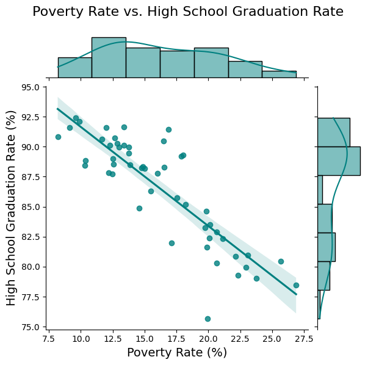

```python
jplot = sns.jointplot(x=poverty_rate_by_state['poverty_rate'], y=hs_graduation_by_state['percent_completed_hs'], kind="reg", color='teal')

jplot.fig.suptitle('Poverty Rate vs. High School Graduation Rate', fontsize=16)
jplot.set_axis_labels('Poverty Rate (%)', 'High School Graduation Rate (%)', fontsize=14)
plt.subplots_adjust(top=0.9)
```

We can observe the same pattern, when the high school graduation rate decreases the poverty rate increases.

#### Using Seaborn's `.regplot()` to show a linear regression between the poverty ratio and the high school graduation ratio.

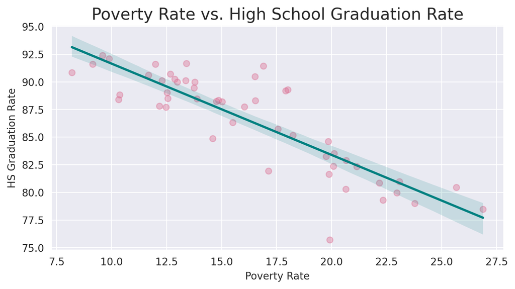

```python
plt.figure(figsize=(8,4), dpi=200)
with sns.axes_style("darkgrid"):
      ax = sns.regplot(x=poverty_rate_by_state['poverty_rate'],
                y=hs_graduation_by_state['percent_completed_hs'],
                scatter_kws = {"color": "palevioletred", 'alpha': 0.4},
                line_kws = {'color': 'teal'})

ax.set(ylabel='HS Graduation Rate',
       xlabel='Poverty Rate')

ax.set_title('Poverty Rate vs. High School Graduation Rate', fontsize=16)
```

```python
X = pd.DataFrame(poverty_rate_by_state, columns=['poverty_rate'])
y = pd.DataFrame(hs_graduation_by_state, columns=['percent_completed_hs'])
```

```python
regression = LinearRegression()
```

```python
regression.fit(X, y)
```

```
LinearRegression()
```

```python
regression.score(X, y)
```

```
0.7424783688743337
```

**The regression score of 0.74 indicates a fairly strong relationship between the poverty rates and the high school graduation rates.**

# Create a Bar Chart with Subsections Showing the Racial Makeup of Each US State

We're going to visualise the share of the white, black, hispanic, asian and native american population in each US State using a bar chart with sub sections. In order to do that we need to aggregate the data by summing the shares for each racial group within each state. After that we have to normalize the data to ensure the sum of the racial shares per state equals 100%.

```python
df_state_sum = df_share_race_city.drop('City', axis='columns')
```

```python
df_state_sum = df_state_sum.groupby('Geographic area').sum().reset_index()
```

```python
df_state_sum[['share_white', 'share_black', 'share_native_american', 'share_asian', 'share_hispanic']] = \
    df_state_sum[['share_white', 'share_black', 'share_native_american', 'share_asian', 'share_hispanic']].div(
        df_state_sum[['share_white', 'share_black', 'share_native_american', 'share_asian', 'share_hispanic']].sum(axis=1), axis=0) * 100
```

```python
df_melted = df_state_sum.melt(id_vars=['Geographic area'],
                    value_vars=['share_white', 'share_black', 'share_native_american', 'share_asian', 'share_hispanic'],
                    var_name='Race',
                    value_name='Racial_share')
```

```python
df_melted['Race'] = df_melted['Race'].str.replace('share_', '')
```

```python
color_sequence = px.colors.sequential.Mint

fig = px.bar(df_melted, y="Racial_share", x="Geographic area", color=df_melted.Race,
               title='Racial Makeup of Each US State',
             color_discrete_sequence=color_sequence)

fig.update_layout(xaxis_title='State',
                  yaxis_title='Racial Share',
                  coloraxis_showscale=False
                  )

fig.show()
fig.write_html('3Racial_makeup_of_each_state.html')
```

[interactive chart not shown]

Vermont (VT) has the highest share of white population - 96.5%. The highest share of black population is in Washington, D.C. with 49.6%. The biggest number (almost 48%) of Native Americans lives in Alaska (AK). The biggest Asian population can be found in Hawaii (HI) - 36%. Hispanic population is the highest in New Mexico (NM) with 35.7%.

**Overall we can see that the most predominant race in most of the states is white.**

# Create Donut Chart by of People Killed by Race

```python
killings_by_race = df_fatalities['race'].value_counts()
```

```python
race_mapping = {
    'B': 'Black',
    'W': 'White',
    'H': 'Hispanic',
    'A': 'Asian',
    'N': 'Native American',
    'O': 'Other'
}
```

```python
races = [race_mapping[abbr] for abbr in killings_by_race.index]
```

```python
colors = ['#66B2B2', '#A0D6D6', '#B2E6B2', '#FF69B4', '#FFCCCB', '#FF9999']
fig = px.pie(names=races, values=killings_by_race.values, title="Number of People Killed by Race")
fig.update_traces(textposition='outside', textinfo='percent+label', marker=dict(colors=colors, line=dict(color='#000000', width=2)))
fig.show()
fig.write_html('4number_of_people_killed_by_race.html')
```

[interactive chart not shown]

We can see that the biggest number of people killed was white (51.3%).

# Create a Chart Comparing the Total Number of Deaths of Men and Women

```python
killings_by_gender = df_fatalities['gender'].value_counts()
```

```python
colors = ['darkslateblue', 'palevioletred']

fig = px.pie(killings_by_gender, values=killings_by_gender.values, names=killings_by_gender.index,
             title='Number of People Killed by Gender', hole=0.3)

fig.update_traces(textposition='inside', textinfo='percent+label', textfont_size=15, marker=dict(colors=colors, line=dict(color='#000000', width=2)))
fig.show()
fig.write_html('5number_of_poeple_killed_by_gender.html')
```

[interactive chart not shown]

**The total number of deaths of men drastically exceeds the number of deaths of women** (only 4.22%).

# Create a Box Plot Showing the Age and Manner of Death

We're going to break out the data by gender and see if there is a difference between men and women in the manner of death.

```python
gendbox = px.box(df_fatalities, x='gender', y='age', color='manner_of_death', notched=True, points='all', title='Victims by Age, Manner of Death and Gender')

gendbox.update_layout(yaxis=dict(type='log'))
gendbox.show()
gendbox.write_html('6victims_by_age_gender.html')
```

[interactive chart not shown]

We have two different manners of death: shot, and shot and tasered. **For both genders shot is the leading manner.** We can also observe the **difference in age between the genders**. The median is a little bit lower for men in both cases (34 and 35 compared to 36 and 37 for women). **The max age for men is much higher** - 91 for shot compared to 71 for women and 76 for shot and tasered compared to 55 for women. Same with min age: 6 and 15 for men compared to 12 and 17 for women.

# Were People Armed?

In what percentage of police killings were people armed? We're going to create a chart that shows what kind of weapon (if any) the deceased was carrying. We're also going to check how many of the people killed by police were unarmed.

```python
armed_victims = df_fatalities['armed'].value_counts()
```

```python
weapons_bar = px.bar(x=armed_victims.index,
               y=armed_victims.values,
               title='Types of Weapons Carried by The Deceased')

weapons_bar.update_layout(xaxis_title='Type of Weapon', yaxis_title='People Count')
weapons_bar.update_xaxes(tickangle=45)
weapons_bar.show()
weapons_bar.write_html('7types_of_weapons.html')
```

[interactive chart not shown]

**In 1398 cases of police killings people were armed with a gun. The second most used weapon was a knife - used in 373 cases.**

```python
unarmed = df_fatalities[df_fatalities['armed'] == 'unarmed']
```

```python
percentage_unarmed = (len(unarmed) / len(df_fatalities)) * 100
percentage_unarmed
```

```
6.7455621301775155
```

**In 6.7% of the killings, people were unarmed.**

# How Old Were the People Killed?

We're going to work out what percentage of people killed were under 25 years old.

```python
under_25 = df_fatalities[df_fatalities['age'] < 25]
```

```python
percentage_under_25 = (len(under_25) / len(df_fatalities)) * 100
```

```python
percentage_under_25
```

```
17.75147928994083
```

**17.75% of people killed were under 25 years old.**

We're going to have a closer look at the distribution of ages of the people killed by police and create a histogram.

```python
fig = px.histogram(df_fatalities,
                   x='age',
                   nbins=30,
                   opacity=0.6,
                   title='Distribution of Ages Of The People Killed by Police')

fig.update_layout(xaxis_title='Age')
fig.show()
fig.write_html('8distribution_of_ages.html')
```

[interactive chart not shown]

We can see that **the most affected group is people between 25 and 29** (403 killings), followed by 30 to 24 year olds (386 killings).

Let's create a separate KDE plot for each race and see if there is a difference between the distributions.

```python
df_races = df_fatalities.dropna(subset=['race'])
```

```python
races = df_races['race'].unique()
```

```python
num_plots = len(races)
palette = sns.color_palette("YlGnBu", num_plots)
```

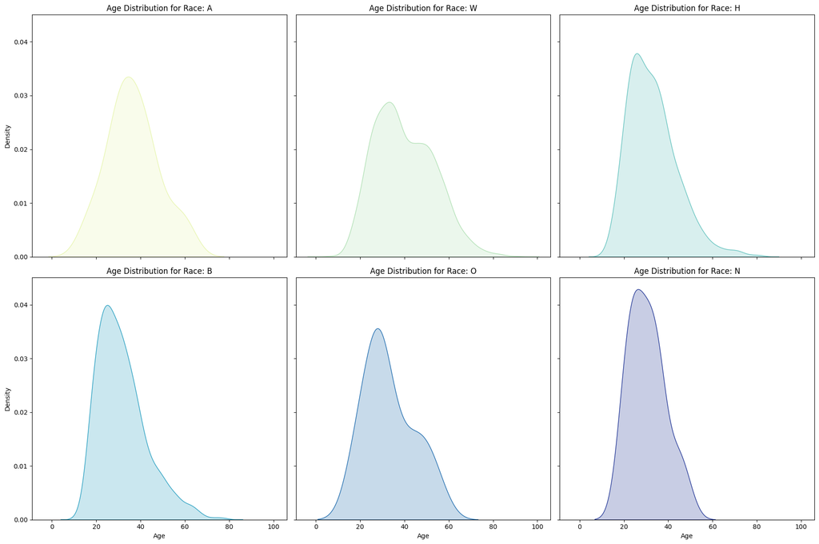

```python
fig, axes = plt.subplots(2, 3, figsize=(18, 12), sharex=True, sharey=True)
axes = axes.flatten()

for i, (race, color) in enumerate(zip(races, palette)):
    sns.kdeplot(df_races[df_races['race'] == race]['age'], ax=axes[i], fill=True, color=color)
    axes[i].set_title(f'Age Distribution for Race: {race}')
    axes[i].set_xlabel('Age')
    axes[i].set_ylabel('Density')

for j in range(i + 1, len(axes)):
    fig.delaxes(axes[j])

plt.tight_layout()
plt.show()
```

- Race A (Asian):

  The density plot for Asians shows a single peak, with the highest density around the late 20s to early 30s. This suggests that most of the police killings within the Asian demographic occur in this age range.
- Race W (White):

  The distribution for Whites is more spread out compared to Asians, with a peak in the early 30s. There is a noticeable number of killings from the mid-20s to the mid-50s.
- Race H (Hispanic):

  Hispanics have a peak density in the late 20s.
- Race B (Black):

  The distribution for Blacks shows a significant peak in the early 20s, suggesting a younger age group is predominantly affected. The density drops off gradually after the peak.
- Race O (Other):

# Race of People Killed

To better understand the number of people killed by race we're going to create a bar chart.

```python
kills_by_race = df_fatalities.groupby('race').size().reset_index(name='number_of_people_killed')
```

```python
kills_by_race = kills_by_race.sort_values('number_of_people_killed', ascending=False)
```

```python
bar = px.bar(x=kills_by_race['race'],
             y=kills_by_race['number_of_people_killed'],
             title='Total Number of People Killed by Race',
             color=kills_by_race['number_of_people_killed'],
             color_continuous_scale='YlGnBu')

bar.update_layout(xaxis_title='Race', yaxis_title='Number of People Killed', coloraxis_showscale=False)

bar.show()
bar.write_html('9total_number_of_people_killed.html')
```

[interactive chart not shown]

We can observe that **the white population is affected the most by the police killings with 1201 people killed.** The second most affected group is Blacks with 618 killings, followed by Hispanic with 423.

# Mental Illness and Police Killings

Let's check what percentage of people killed by police have been diagnosed with a mental illness.

```python
mental_illness = df_fatalities[df_fatalities['signs_of_mental_illness'] == True]
```

```python
percentage_mental_illness = (len(mental_illness) / len(df_fatalities)) * 100
percentage_mental_illness
```

```
24.970414201183434
```

**Almost 25% of people killed by the police have been diagnosed with a mental illness.**

# In Which Cities Do the Most Police Killings Take Place?

To find out which cities are the most dangerous, we're going to create a chart ranking the top 10 cities with the most police killings.

```python
top_10_cities = df_fatalities['city'].value_counts().head(10).index
```

```python
df_top_10 = df_fatalities[df_fatalities['city'].isin(top_10_cities)]
```

```python
killings_by_city = df_top_10.groupby('city').size().reset_index(name='number_of_killings')
```

```python
killings_by_city = killings_by_city.sort_values('number_of_killings', ascending=False)
```

```python
bar = px.bar(x=killings_by_city['city'],
             y=killings_by_city['number_of_killings'],
             title='Top 10 Cities With The Most Police Killings',
             color=killings_by_city['number_of_killings'],
             color_continuous_scale='Greys')

bar.update_layout(xaxis_title='City', yaxis_title='Total Number of People Killed', coloraxis_showscale=False)

bar.show()
bar.write_html('10top_10_cities')
```

[interactive chart not shown]

**Los Angeles has the highest number of police killings (39)**, followed by Phoenix with 31 killings and then Houston with 27.

# Rate of Death by Race

We're going to find the share of each race in the top 10 most dangerous cities.

```python
death_by_race = df_top_10.groupby(['city', 'race']).size().reset_index(name='number_of_deaths')
```

```python
death_by_race = death_by_race.sort_values('number_of_deaths', ascending=False)
```

```python
color_sequence = px.colors.sequential.Brwnyl

bar = px.bar(x=death_by_race['city'],
             y=death_by_race['number_of_deaths'],
             title='Top 10 Cities With The Most Police Killings by Race',
             color=death_by_race['race'],
             color_discrete_sequence=color_sequence)

bar.update_layout(xaxis_title='City', yaxis_title='Total Number of People Killed', coloraxis_showscale=False)

bar.show()
bar.write_html('11top_10_cities_by_race.html')
```

[interactive chart not shown]

Let's take a closer look at the city with the highest number of killings - Los Angeles. **The most affected group in LA is Hispanic (H)**, followed by black (B), then white (W) and lastly with only 1 killing are Asians (A). Interestingly Hispanics are not the leading race group in the state of California - they make up 26.6% of the state's population. California's most populous group is Whites with 64.5%.

**Chicago stands out as out of the total of 24 killings, as many as 21 were black people.** These numbers are worrying especially because in the state of Illinois, the population is predominantly white (88.7%) and Blacks only make up 4.6%.

# Create a Choropleth Map of Police Killings by US State

```python
killings_by_state = df_fatalities.groupby('state').size().reset_index(name='number_of_deaths')
```

```python
fig = px.choropleth(killings_by_state,
                    locations='state',
                    locationmode='USA-states',
                    color='number_of_deaths',
                    scope='usa',
                    hover_name='state',
                    color_continuous_scale='amp')
fig.update_layout(title_text='Map of Police Killings by US State')
fig.show()
fig.write_html('12map_of_police_killings_by_state')
```

[interactive chart not shown]

We can see that overall there are **more police killings in the south of the country with California (424 killings), Texas (225) and Florida (154) being the three most dangerous states.**

Let's check if our map coincides in any way with a map of poverty rates.

```python
poverty_rate = df_pct_poverty.groupby('Geographic Area', as_index=False).agg({'poverty_rate': pd.Series.mean})
```

```python
fig = px.choropleth(poverty_rate,
                    locations='Geographic Area',
                    locationmode='USA-states',
                    color='poverty_rate',
                    scope='usa',
                    hover_name='Geographic Area',
                    color_continuous_scale='amp')
fig.update_layout(title_text='Map of Average Poverty Rates by US State')
fig.show()
fig.write_html('13map_of_poverty_rates.html')
```

[interactive chart not shown]

**The poverty rates are higher in the south of the country.** The 3 most dangerous states: California, Texas and Florida have medium poverty rates (ranging from 17.1% to 19.9%) but they're definitely not the highest.

The state of **Mississippi has the highest poverty rate - 26.9%.**

# Number of Police Killings Over Time

Our dataset starts on 2015-01-03 and ends on 2017-12-07, which means we don't have complete data for the last month of 2017. We have to extract the year from the date column first and then create a line chart.

```python
df_fatalities['year'] = df_fatalities['date'].dt.year
```

```python
killings_over_time = df_fatalities.groupby('year').size().reset_index(name='number_of_killings')
```

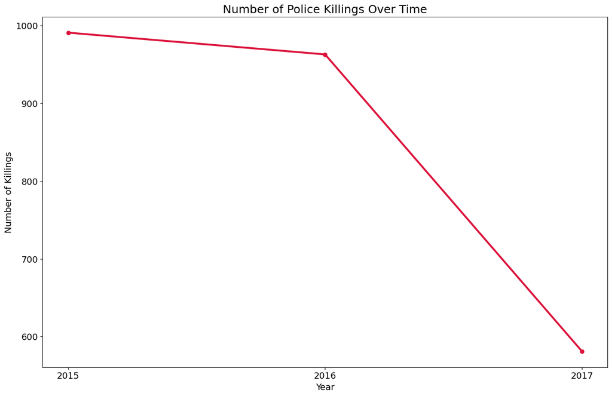

```python
plt.figure(figsize=(16,10))
plt.xticks(ticks=[2015, 2016, 2017], fontsize=14)
plt.yticks(fontsize=14)
plt.xlabel('Year', fontsize=14)
plt.ylabel('Number of Killings', fontsize=14)
plt.title('Number of Police Killings Over Time', fontsize=18)

plt.plot(killings_over_time.year, killings_over_time.number_of_killings, color='crimson', marker='o', linewidth=3)
```

In 2015 there were just under 1000 police killings, the number has decreased slightly in 2016 and then plummeted to less than 600 in 2017.